# HW example

Caleb

Due: 11:59 pm, Aug 29th, 2017

## Question A (10 pts)

#### 1. Calculate $\sum_{i=1}^{1000} \frac{1}{i^2}$ (5 pts)

```r
## Your code
i <- 1:1000
result_A1 <- sum(1/i^2)
result$A1 <- result_A1 ## replace NULL with your answer (by replacing NULL with the variable containing your answer)
```

#### 2. Fibonacci number follows the following recurrence relation:

$F_n = F_{n-1} + F_{n-2}$. Given the seed value $F_1 = 1$ and $F_2 = 1$, what is $F_{100}$? (5 pts)

```r
## Your code
N <- 100
F <- rep(NA, N)
F[1] <- 1
F[2] <- 1
for(n in 3:N){
  F[n] <- F[n-1] + F[n-2]
}

result$A2 <- F[N] ## replace NULL with your answer (by replacing NULL with the variable containing your answer)
```

## Question B (10 pts)

#### 1. In R base package, there is cars’ data. data(cars), plot speed (x axis) vs dist (y axis).

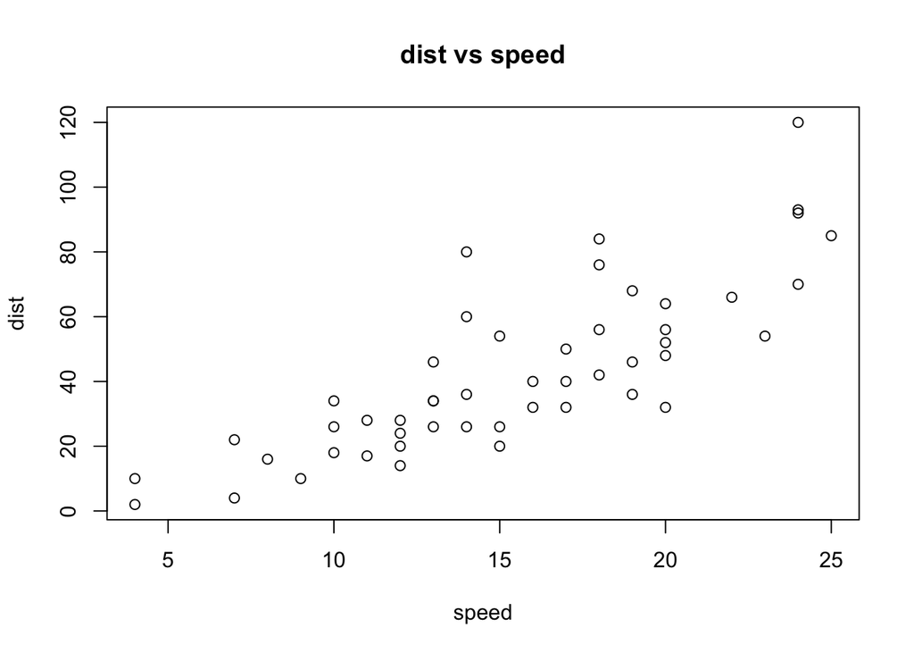

```r
## Your code
plot(x=cars$speed, y = cars$dist, xlab="speed", ylab="dist", main="dist vs speed")
```

## Question C (10 pts)

In R base package, there is mtcars’ data. data(mtcars)

#### 1. Fit a linear model: treat mpg as response variable and cyl, disp, hp and drat as predictors. (5 pts)

```r
## Your code
lmfit <- lm(mpg ~ cyl + disp + hp + drat, data=mtcars)
```

#### 2. Find the p-value for cyl. (5 pts)

```r
## Your code
pvalue <- summary(lmfit)$coefficients["cyl", "Pr(>|t|)"]

result$C2 <- pvalue ## replace NULL with your answer (by replacing NULL with the variable containing your answer)
```

## Note:

#### Save your result as Rdata. So Auto grading can be performed.

The chunk of code will verify that the Rdata contains your name, GatorLinkID, answers to all questions

```r
verify <- function(result){
  ## first verify your basic information, if not, error will come up.
  if(is.null(result$firstName)){
    stop("firstName is missing")
  } else {
    cat("Name:", result$firstName, " ")
  }
  if(is.null(result$lastName)){
    stop("lastName is missing")
  } else {
    cat(result$lastName, "\n")
  }
  if(is.null(result$GatorLinkID)){
    stop("GatorLinkID is missing")
  } else {
    cat("GatorLinkID:", result$GatorLinkID, "\n")
  }
  if(is.null(result$teammate)){
    cat("You have no teammate\n")
  } else {
    cat("Your teammate is", result$teammate, "\n")
  }

  ## second verify if you have provide an answer, if not, warning will come up.
  completeAnswer <- TRUE
  if(is.null(result$A1)) {
    warning("Question A1 is answered")
    completeAnswer <- FALSE
  }
  if(is.null(result$A2)) {
    warning("Question A2 is answered")
    completeAnswer <- FALSE
  }
  if(is.null(result$C2)) {
    warning("Question C2 is answered")
    completeAnswer <- FALSE
  }
  if(completeAnswer) cat("Congratulations! All questions are answered!\n")

}

verify(result) ## verify your result
```

[output not shown]

```r
save(result, file="hw0_Lastname_Firstname.Rdata") ## save your result
```

### Homework should be uploaded to courseweb:

1. Save your compiled result as html/pdf file. Rename the file name as: hw0_lastname_firstname.html or hw0_lastname_firstname.pdf.
2. RMD file is not required.
3. Save your result as Rdata and name it as hw0_lastname_firstname.Rdata.
4. You can upload to courseweb (1 and 3) or 4.

### If you generate a figure, please write appropriate figure title, labels, legend if necessary.

### If your code is not intuitive, please write comments to make the code readible.